## Cross-validation

## Resampling Methods

- **Resampling methods** involve repeatedly drawing samples from a *training* set and refitting a model of interest on each sample in order to obtain additional information about the fitted model.
- **Cross-validation** and the **bootstrap** are the best known.
- They are used for evaluating model's performance (*model assessment*) and selecting the best model (*model selection*).
- For example, they can be used to get the standard deviation and bias of our parameter estimates, as well as estimates of the test error associated with a given statistical learning method, or to select the appropriate level of flexibility.

## Validation-set approach

- Here we randomly divide the available set of samples into two parts: a *training set* and a *validation or hold-out set*.
- The model is fit on the training set, and the fitted model is used to predict the responses for the observations in the validation set.
- The resulting validation-set error provides an estimate of the test error. This is typically assessed using MSE in the case of a quantitative response and misclassification rate in the case of a qualitative (discrete) response.

The Validation process

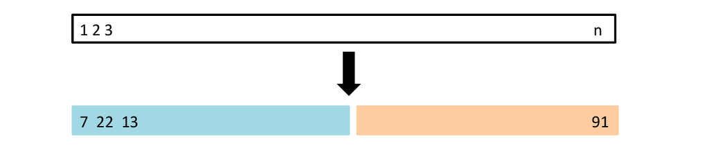

The validation process.

A random splitting into two halves: left part is training set, right part is validation set.

Example: the `Auto` data set

`mpg` (gas mileage in miles per gallon) vs `horsepower`.

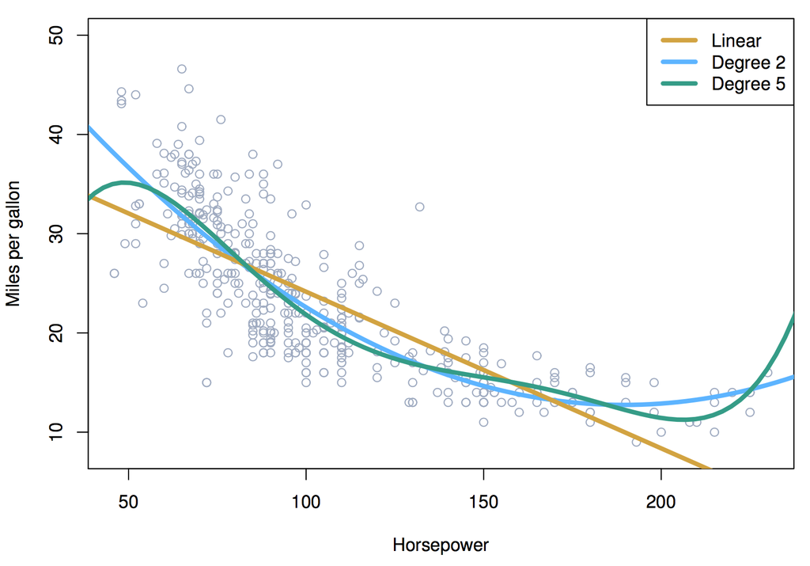

The `Auto` data set.

The data suggest a curved relationship.

We Want to compare linear vs higher-order polynomial terms in a linear regression

\[ {mpg}=\beta_{0}+\beta_{1}\times {horsepower} + \beta_{2} \times {\text horsepower}^{2} +\epsilon\\ {mpg}=\beta_{0}+\beta_{1}\times {horsepower} + \ldots + \beta_{5}\times {horsepower}^{5} + \epsilon\\ \]

We randomly split the 392 observations into two sets, a training set containing 196 of the data points, and a validation set containing the remaining 196 observations.

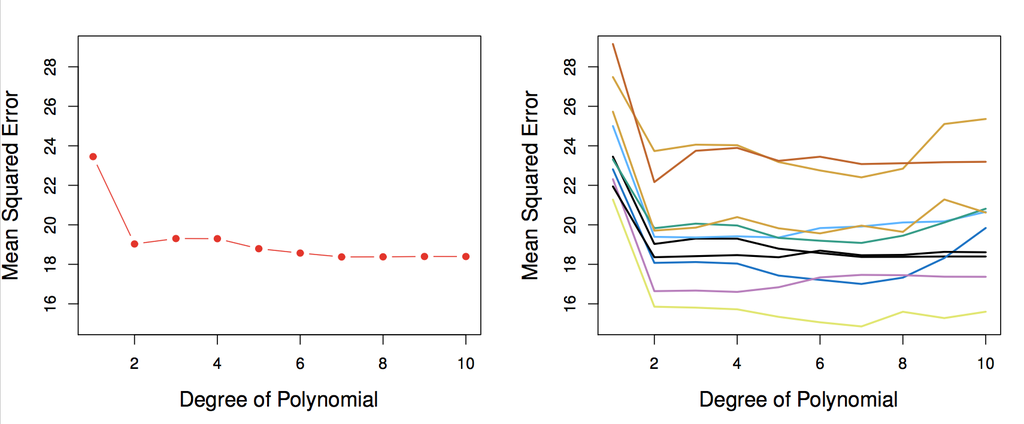

Validation-set approach for the `Auto` data set.

Left panel shows single split; right panel shows multiple splits.

Drawbacks of validation set approach

- The validation estimate of the test error can be **highly variable**, depending on precisely which observations are included in the training set and which are in the validation set.
- In the validation approach, only a subset of the observations - those that are included in the training set - are used to fit the model. This suggests that the validation set error may tend to **overestimate** the test error for the model fit on the entire data set. *Why?*

## K-fold Cross-validation

- Widely used approach for estimating test error.
- Estimates can be used to select best model, and to give an idea of the test error of the final chosen model.
- Idea is to randomly divide the data into \(K\) equal-sized parts. We leave out part \(k\), fit the model to the other \(K-1\) parts (combined), and then obtain predictions for the left-out \(k\)th part.
- This is done in turn for each part \(k=1,2,\ldots,K\), and then the results are combined.

\(K\)-fold Cross-validation in detail

Divide the data into \(K\) roughly equal-sized parts (\(K=5\) here).

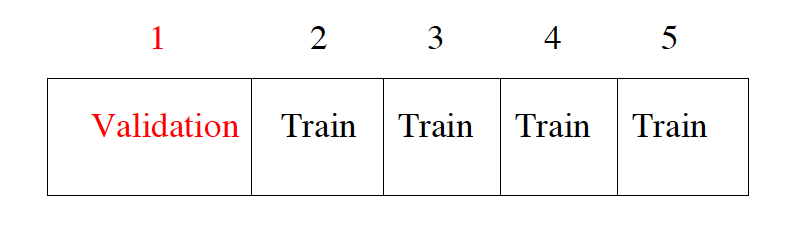

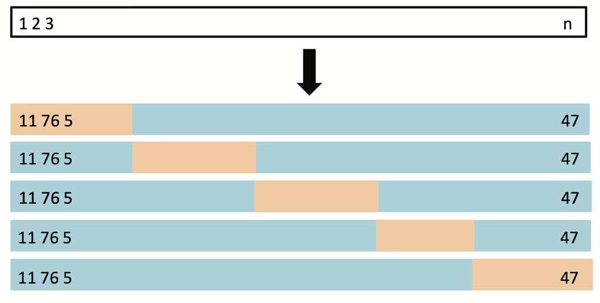

\(5\)-fold Cross-validation.

- Let the \(K\) parts be \(C_{1}, C_{2}, \ldots, C_{K}\), where \(C_{k}\) denotes the indices of the observations in part \(k\). There are \(n_{k}\) observations in part \(k\): if \(n\) is a multiple of \(K\), then \(n_{k} = n/K\).
- Compute \[ {\rm CV}_{K}=\sum_{k=1}^{K}\frac{n_{k}}{n}\,{\rm MSE}_{k} \] where \({\rm MSE}_{k}=\sum_{i\in C_{k}}(y_{i}-\hat y_{i})^{2}/n_{k}\), and \(\hat y_{i}\) is the fit for observation \(i\), obtained from the data with part \(k\) removed.
- Setting \(K = n\) yields \(n\)-fold or **leave-one out** cross-validation (LOOCV).

LOOCV

Advantages wrt the validation set approach

- Less bias: LOOCV will give approximately unbiased estimates of the test error
- Performing LOOCV multiple times will always yield the same results

10-fold CV were run nine separate times, each with a different random split of the data into ten parts.

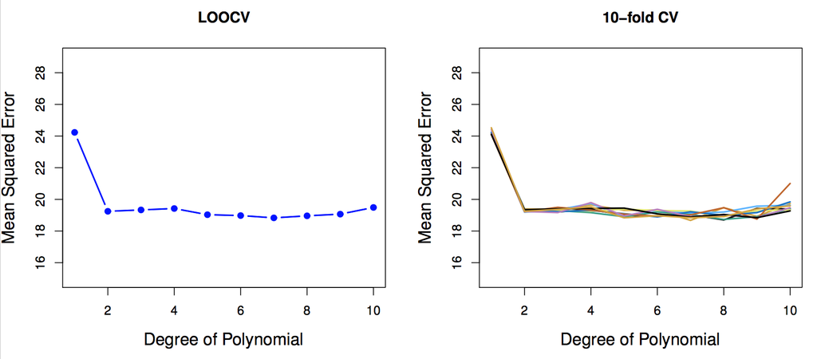

\(k\)-fold cv applied on the `Auto` data set.

Advantages wrt the validation set approach

- Variability is typically much lower
- 5/10-fold CV will lead to an intermediate level of bias

A nice special case!

- With least-squares linear or polynomial regression, an amazing shortcut makes the cost of LOOCV the same as that of a single model fit! The following formula holds: \[ {\rm CV}_{n}=\frac{1}{n}\sum_{i=1}^{n}\left(\frac{y_{i}-\hat y_{i}}{1-h_{i}}\right)^{2} \] where \(\hat y_{i}\) is the \(i\)th fitted value from the original least squares fit, and \(h_{i}\) is the **leverage** (diagonal of the ``hat'' matrix). This is like the ordinary MSE, except the \(i\)th residual is divided by \(1-h_{i}\).

LOOCV vs \(K\)-fold CV

- LOOCV has the potential to be computationally expensive (except for linear models fit by least squares).
- From the perspective of bias reduction, it is clear that LOOCV is to be preferred to k-fold CV.
- But typically LOOCV doesn't *shake up* the data enough. The estimates from each fold are highly correlated and hence their average can have high variance.
- A better choice is \(K = 5\) or 10, as these values have been shown empirically to yield test error estimates that suffer neither from excessively high bias nor from very high variance.